# What Features drive computer price?

## Purpose

The aim of this data project is to determine what features of a computer (RAM, Hard drive, speed, ect.) are indicators of the price of a computer.

#### Outline

1: Data overview

2: Examine if a categorical feature of having a cd player in a computer influence price?

3: Look if other features drive computer price

4: Conclusion for what drives computer prices

# 1. Data overview

```python
# Import packages and data
import pandas as pd
import numpy as np
import seaborn as sn
import matplotlib.pyplot as plt
from sklearn import linear_model
import statsmodels.api as sm
from statsmodels.stats.outliers_influence import variance_inflation_factor


df = pd.read_csv (r'C:\Users\kevin\Desktop\Data science\MLPy\Projects\Computers.csv')
df.head(11)
```

|  | price | speed | hd | ram | screen | cd | ads |
| --- | --- | --- | --- | --- | --- | --- | --- |
| 0 | 1499 | 25 | 80 | 4 | 14 | no | 94 |
| 1 | 1795 | 33 | 85 | 2 | 14 | no | 94 |
| 2 | 1595 | 25 | 170 | 4 | 15 | no | 94 |
| 3 | 1849 | 25 | 170 | 8 | 14 | no | 94 |
| 4 | 3295 | 33 | 340 | 16 | 14 | no | 94 |
| 5 | 3695 | 66 | 340 | 16 | 14 | no | 94 |
| 6 | 1720 | 25 | 170 | 4 | 14 | yes | 94 |
| 7 | 1995 | 50 | 85 | 2 | 14 | no | 94 |
| 8 | 2225 | 50 | 210 | 8 | 14 | no | 94 |
| 9 | 2575 | 50 | 210 | 4 | 15 | no | 94 |
| 10 | 2195 | 33 | 170 | 8 | 15 | no | 94 |

```python
df.info()
#We see cd player is an object, meaning it is categorical
```

```
<class 'pandas.core.frame.DataFrame'>
RangeIndex: 6259 entries, 0 to 6258
Data columns (total 7 columns):
 #   Column  Non-Null Count  Dtype
---  ------  --------------  -----
 0   price   6259 non-null   int64
 1   speed   6259 non-null   int64
 2   hd      6259 non-null   int64
 3   ram     6259 non-null   int64
 4   screen  6259 non-null   int64
 5   cd      6259 non-null   object
 6   ads     6259 non-null   int64
dtypes: int64(6), object(1)
memory usage: 342.4+ KB
```

```python
df.isnull().values.any()
# no missing data
```

```
False
```

```python
df.describe()
#summary stats.
```

|  | price | speed | hd | ram | screen | ads |
| --- | --- | --- | --- | --- | --- | --- |
| count | 6259.000000 | 6259.000000 | 6259.000000 | 6259.000000 | 6259.000000 | 6259.000000 |
| mean | 2219.576610 | 52.011024 | 416.601694 | 8.286947 | 14.608723 | 221.301007 |
| std | 580.803956 | 21.157735 | 258.548445 | 5.631099 | 0.905115 | 74.835284 |
| min | 949.000000 | 25.000000 | 80.000000 | 2.000000 | 14.000000 | 39.000000 |
| 25% | 1794.000000 | 33.000000 | 214.000000 | 4.000000 | 14.000000 | 162.500000 |
| 50% | 2144.000000 | 50.000000 | 340.000000 | 8.000000 | 14.000000 | 246.000000 |
| 75% | 2595.000000 | 66.000000 | 528.000000 | 8.000000 | 15.000000 | 275.000000 |
| max | 5399.000000 | 100.000000 | 2100.000000 | 32.000000 | 17.000000 | 339.000000 |

#### There are 6,259 computers in the data set, with an average price of `$2,219.58`. The least expensive computer is `$949.00` and the most expensive is `$5,399.00`

# 2. Does having a cd player in a computer influence price?

```python
df.groupby('cd').mean()
# We see computers with a cd player have an average price of $2,342.61
# and the computers without a cd player have an average price of $2,112.81.
```

| cd | price | speed | hd | ram | screen | ads |
| --- | --- | --- | --- | --- | --- | --- |
| no | 2112.811996 | 46.921218 | 295.324978 | 5.986870 | 14.499552 | 225.559534 |
| yes | 2342.605571 | 57.876204 | 556.353508 | 10.937414 | 14.734525 | 216.393741 |

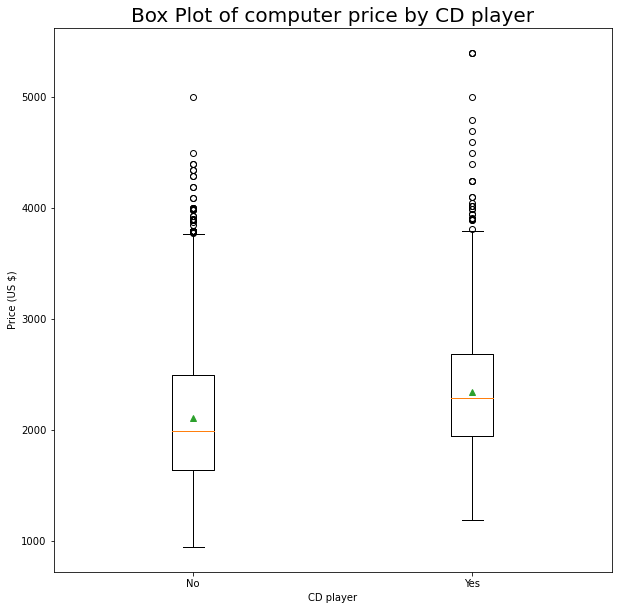

```python
fig = plt.figure(figsize= (10, 10))
ax = fig.add_subplot(111)

ax.set_title("Box Plot of computer price by CD player", fontsize= 20)
ax.set

data = [df['price'][df['cd'] == 'no'],
        df['price'][df['cd'] == 'yes']]

ax.boxplot(data,
           labels= ['No', 'Yes'],
           showmeans= True)

plt.xlabel("CD player")
plt.ylabel("Price (US $)")

plt.show()
```

#### Above is a plot showing computer price by CD player status. We can see there is a difference, but is the difference in price significantly different?

```python
import statsmodels.api as sm
from statsmodels.formula.api import ols

model = ols('price ~ C(cd)', data=df).fit()
aov_table = sm.stats.anova_lm(model, typ=2)
aov_table
```

|  | sum_sq | df | F | PR(>F) |
| --- | --- | --- | --- | --- |
| C(cd) | 8.221284e+07 | 1.0 | 253.549401 | 5.439449e-56 |
| Residual | 2.028819e+09 | 6257.0 | NaN | NaN |

### We can see that computers with a cd player are significantly more expensive than computers without a cd player. However, I am inclined to believe there are other reason beyond a cd player that drive computer prices. If having a cd player made computers companies more money why would they remove the cd player (besides the practical notion of cd's becoming outdated). Let's explore

# 3. What other features drive computer price?

### First let's see how the features correlate to the price of computers

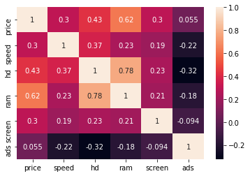

```python
df.corr()
corrMatrix = df.corr()
sn.heatmap(corrMatrix, annot=True)
plt.show()
```

### Let's plot these two important features (RAM and hard drive) to see their relationship with price

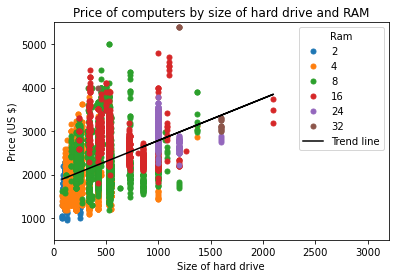

```python
fig, ax = plt.subplots()
groups = df.groupby('ram')
for name, group in groups:
    ax.plot(group.hd, group.price, marker='o', linestyle='', ms=5,
label=name)
plt.xlabel("Size of hard drive")
plt.ylabel("Price (US $)")
plt.title('Price of computers by size of hard drive and RAM')
plt.xlim([0, 3200])
plt.ylim([500, 5500])


# calc the trendline
z = np.polyfit(df['hd'], df['price'], 1)
p = np.poly1d(z)
plt.plot(df['hd'], p(df['hd']),"black", label= 'Trend line')
plt.legend(title = 'Ram')
```

### Now let's look at statistical models examining the relationship between price and the features. We will use a multiple linear regression. Before we run the regression, let's see if we have multicollinearity between any of the features. Multicollinearity determines if any features have overlap with each other, meaning one variable can linearly predict other variable(s).

```python
def calc_vif(X):

    # Calculating VIF
    vif = pd.DataFrame()
    vif["variables"] = X.columns
    vif["VIF"] = [variance_inflation_factor(X.values, i) for i in range(X.shape[1])]

    return(vif)

X = df.iloc[:,([1,2,3,4,6])] #Not include cd because it is a binary factor that we will look at later
calc_vif(X)
```

|  | variables | VIF |
| --- | --- | --- |
| 0 | speed | 8.436940 |
| 1 | hd | 10.821676 |
| 2 | ram | 8.187562 |
| 3 | screen | 22.752925 |
| 4 | ads | 10.479972 |

#### Given the VIF's it appears the screen feature has high multicollinearity with the other features. This means the screen feature has a lot of overlap with the other features and we do not want to include 'screen' into the model because it will be explaining more than it should becuase we are double dipping in prediciting price as indicated by the high VIF. Typically, a VIF near 1 is good, VIF between 1-5 is moderate, and VIF 5+ indicates a lot of overlap between features.

# Full multiple linear regression (OLS estimation)

```python
X = df[['speed','hd', 'ram', 'ads']] # here we have 4 variables for multiple regression.
Y = df['price']

# with sklearn
regr = linear_model.LinearRegression()
regr.fit(X, Y)

print('Intercept: \n', regr.intercept_)
print('Coefficients: \n', regr.coef_)


# with statsmodels
X = sm.add_constant(X) # adding a constant

model = sm.OLS(Y, X).fit()
predictions = model.predict(X)

print_model = model.summary()
print(print_model)
```

```
Intercept:
 1104.7681362742542
Coefficients:
 [ 6.31500598 -0.36535502 75.15282062  1.42691913]
                            OLS Regression Results
==============================================================================
Dep. Variable:                  price   R-squared:                       0.463
Model:                            OLS   Adj. R-squared:                  0.463
Method:                 Least Squares   F-statistic:                     1348.
Date:                Mon, 22 Feb 2021   Prob (F-statistic):               0.00
Time:                        16:46:07   Log-Likelihood:                -46769.
No. Observations:                6259   AIC:                         9.355e+04
Df Residuals:                    6254   BIC:                         9.358e+04
Df Model:                           4
Covariance Type:            nonrobust
==============================================================================
                 coef    std err          t      P>|t|      [0.025      0.975]
------------------------------------------------------------------------------
const       1104.7681     25.777     42.858      0.000    1054.236    1155.300
speed          6.3150      0.277     22.830      0.000       5.773       6.857
hd            -0.3654      0.036    -10.142      0.000      -0.436      -0.295
ram           75.1528      1.536     48.923      0.000      72.141      78.164
ads            1.4269      0.077     18.558      0.000       1.276       1.578
==============================================================================
Omnibus:                     1802.522   Durbin-Watson:                   1.510
Prob(Omnibus):                  0.000   Jarque-Bera (JB):             5772.763
Skew:                           1.462   Prob(JB):                         0.00
Kurtosis:                       6.686   Cond. No.                     2.52e+03
==============================================================================

Notes:
[1] Standard Errors assume that the covariance matrix of the errors is correctly specified.
[2] The condition number is large, 2.52e+03. This might indicate that there are
strong multicollinearity or other numerical problems.
```

#### In the Full model, the 4 features explain 46.3% of the variane in computer prices. What is more interesting is that RAM and computer speed have the strongest relationship with price. Let's see how a reduced model compares to the full model. The reason for running a reduced model is in simplicity and computing efficiency, which will not make much of a difference for this small of a data set, but for much larger data sets, the efficiency is an important factor to consider.